# QEUEUE

Antrian adalah struktur data linier yang mengikuti prinsip Masuk Pertama Keluar Pertama (FIFO).

- Sistem ini mengikuti prinsip " Masuk Pertama, Keluar Pertama " (FIFO) , di mana elemen pertama yang ditambahkan ke antrian adalah elemen pertama yang dikeluarkan.
- Ini digunakan sebagai penyangga dalam sistem komputer ketika terjadi ketidaksesuaian kecepatan antara dua perangkat yang saling berkomunikasi. Misalnya, CPU dan keyboard, dua perangkat dalam jaringan.
- Antrian juga digunakan dalam algoritma Sistem Operasi seperti Penjadwalan CPU dan Manajemen Memori, serta banyak algoritma standar seperti Pencarian Lebar Pertama pada Graf, Penelusuran Urutan Level pada Pohon.

Operasi dasar yang dapat kita lakukan pada antrian adalah: Enqueue:Menambahkan elemen baru ke dalam antrian. Dequeue: Menghapus dan mengembalikan elemen pertama (terdepan) dari antrian. Peek:Mengembalikan elemen pertama dalam antrian. isEmpty:Memeriksa apakah antrian kosong. Size: Menemukan jumlah elemen dalam antrian.

## Implementasi Antrian menggunakan Daftar Python

```python
queue = []

# Enqueue
queue.append('A')
queue.append('B')
queue.append('C')
print("Queue: ", queue)

# Peek
frontElement = queue[0]
print("Peek: ", frontElement)

# Dequeue
poppedElement = queue.pop(0)
print("Dequeue: ", poppedElement)

print("Queue after Dequeue: ", queue)

# isEmpty
isEmpty = not bool(queue)
print("isEmpty: ", isEmpty)

# Size
print("Size: ", len(queue))
```

```
Queue:  ['A', 'B', 'C']
Peek:  A
Dequeue:  A
Queue after Dequeue:  ['B', 'C']
isEmpty:  False
Size:  2
```

## Mengimplementasikan Kelas Antrian

```python
class Queue:
  def __init__(self):
    self.queue = []

  def enqueue(self, element):
    self.queue.append(element)

  def dequeue(self):
    if self.isEmpty():
      return "Queue is empty"
    return self.queue.pop(0)

  def peek(self):
    if self.isEmpty():
      return "Queue is empty"
    return self.queue[0]

  def isEmpty(self):
    return len(self.queue) == 0

  def size(self):
    return len(self.queue)

# Create a queue
myQueue = Queue()

myQueue.enqueue('A')
myQueue.enqueue('B')
myQueue.enqueue('C')

print("Queue: ", myQueue.queue)
print("Peek: ", myQueue.peek())
print("Dequeue: ", myQueue.dequeue())
print("Queue after Dequeue: ", myQueue.queue)
print("isEmpty: ", myQueue.isEmpty())
print("Size: ", myQueue.size())
```

[output not shown]

## Implementasi Antrian menggunakan Daftar Berantai

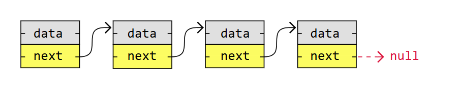

Salah satu keuntungan besar menggunakan linked list adalah node disimpan di mana pun ada ruang kosong di memori, node tidak perlu disimpan berdekatan satu sama lain seperti elemen yang disimpan dalam array. Keuntungan lain dari linked list adalah ketika menambahkan atau menghapus node, node lain dalam list tidak perlu digeser.

```python
class Node:
  def __init__(self, data):
    self.data = data
    self.next = None

class Queue:
  def __init__(self):
    self.front = None
    self.rear = None
    self.length = 0

  def enqueue(self, element):
    new_node = Node(element)
    if self.rear is None:
      self.front = self.rear = new_node
      self.length += 1
      return
    self.rear.next = new_node
    self.rear = new_node
    self.length += 1

  def dequeue(self):
    if self.isEmpty():
      return "Queue is empty"
    temp = self.front
    self.front = temp.next
    self.length -= 1
    if self.front is None:
      self.rear = None
    return temp.data

  def peek(self):
    if self.isEmpty():
      return "Queue is empty"
    return self.front.data

  def isEmpty(self):
    return self.length == 0

  def size(self):
    return self.length

  def printQueue(self):
    temp = self.front
    while temp:
      print(temp.data, end=" -> ")
      temp = temp.next
    print()

# Create a queue
myQueue = Queue()

myQueue.enqueue('A')
myQueue.enqueue('B')
myQueue.enqueue('C')

print("Queue: ", end="")
myQueue.printQueue()
print("Peek: ", myQueue.peek())
print("Dequeue: ", myQueue.dequeue())
print("Queue after Dequeue: ", end="")
myQueue.printQueue()
print("isEmpty: ", myQueue.isEmpty())
print("Size: ", myQueue.size())
```

```
Queue: A -> B -> C ->
Peek:  A
Dequeue:  A
Queue after Dequeue: B -> C ->
isEmpty:  False
Size:  2
```